# IODS course project

Niko

# About the project

*Write a short description about the course and add a link to your GitHub repository here. This is an R Markdown (.Rmd) file so you can use R Markdown syntax.*

Well I’m feeling rather good about the course, looking forward to it. I’ve used R before, but not necessarily for routine statistics but more specialised things, such as phylogenetic analysis and especially graphic formatting. Quite keen on studying actual statistics and how to implement that routinely in R. Heard about the course from the email list, would have never found it any other way! Here’s the link for my GitHub repository: https://github.com/nikjohan/IODS-project.

# Week 2: linear regression and model validation

The data used here is derived from an introductory course in social statistics, organised in 2014. The full detailed metadata can be accessed here: https://www.mv.helsinki.fi/home/kvehkala/JYTmooc/JYTOPKYS3-meta.txt.

Inputting data to R

```r
#set working directory
setwd("C:\\Users\\Niko\\Documents\\IODS-project\\data")
learning2014analysis <- read.csv("learning2014analysis.csv", header = T)
```

The data consists of 7 variables and 166 observations, as explored below in R code.

```r
str(learning2014analysis)
```

```
## 'data.frame':    166 obs. of  7 variables:
##  $ age     : int  53 55 49 53 49 38 50 37 37 42 ...
##  $ attitude: int  37 31 25 35 37 38 35 29 38 21 ...
##  $ gender  : Factor w/ 2 levels "F","M": 1 2 1 2 2 1 2 1 2 1 ...
##  $ points  : int  25 12 24 10 22 21 21 31 24 26 ...
##  $ deep    : num  3.58 2.92 3.5 3.5 3.67 ...
##  $ stra    : num  3.38 2.75 3.62 3.12 3.62 ...
##  $ surf    : num  2.58 3.17 2.25 2.25 2.83 ...
```

attitude is a numerical estimate of the student’s attitude towards statistics, based on a questionnaire. Points are the exam points on the final exam of the course. Age and gender are collected for each participant. Deep, stra and surf are variables about different approaches to statistics: a deep approach (deep), a strategic approach (stra) and a surface approach (surf). The data is derived from questions targeted for each specific approach on a Likert scale (1-5). All question scores for a given approach have been averaged to form a single deep, stra or surf value per correspondent. In the data wrangling section those correspondents without a exam score (points = 0, 17 correspondents) have been excluded.

Graphical overview of the data with a scatterplot matrix

```r
library(GGally)
```

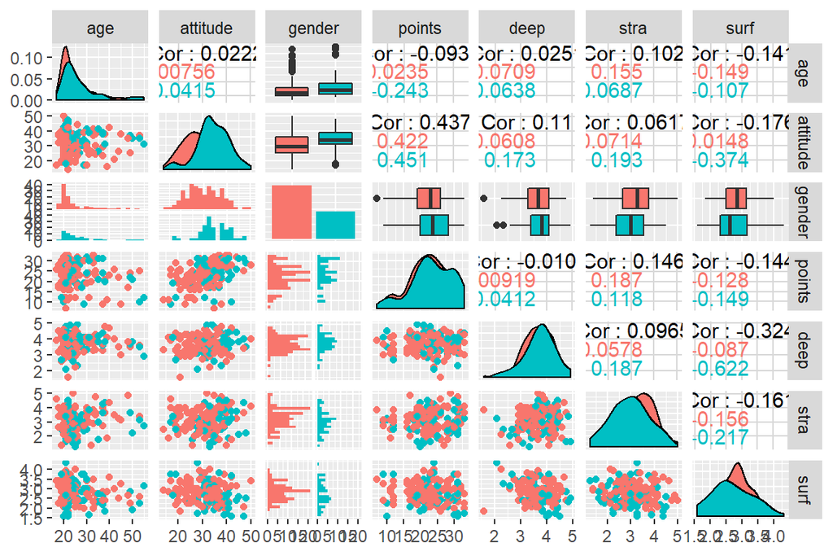

```r
library(ggplot2)
p <- ggpairs(learning2014analysis, mapping = aes(col = gender), lower = list(combo = wrap("facethist", bins = 20)))
p
```

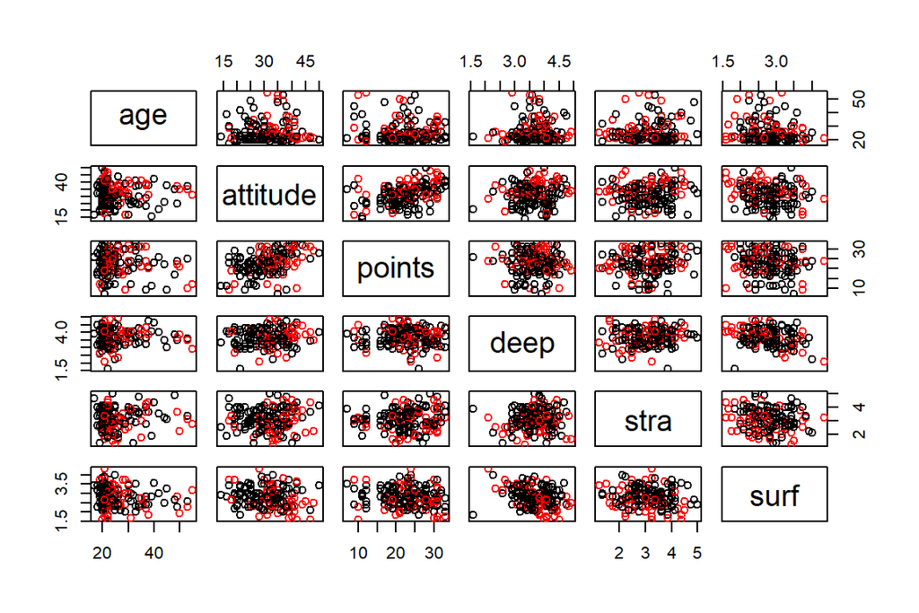

```r
pairs(learning2014analysis[-3], col = learning2014analysis$gender)
```

Summary statistics for the data:

```r
summary(learning2014analysis)
```

```
##       age           attitude     gender      points           deep
##  Min.   :17.00   Min.   :14.00   F:110   Min.   : 7.00   Min.   :1.583
##  1st Qu.:21.00   1st Qu.:26.00   M: 56   1st Qu.:19.00   1st Qu.:3.333
##  Median :22.00   Median :32.00           Median :23.00   Median :3.667
##  Mean   :25.51   Mean   :31.43           Mean   :22.72   Mean   :3.680
##  3rd Qu.:27.00   3rd Qu.:37.00           3rd Qu.:27.75   3rd Qu.:4.083
##  Max.   :55.00   Max.   :50.00           Max.   :33.00   Max.   :4.917
##       stra            surf
##  Min.   :1.250   Min.   :1.583
##  1st Qu.:2.625   1st Qu.:2.417
##  Median :3.188   Median :2.833
##  Mean   :3.121   Mean   :2.787
##  3rd Qu.:3.625   3rd Qu.:3.167
##  Max.   :5.000   Max.   :4.333
```

As we are trying to predict and explain the final exam score, the points -variable is the target variable. Firstly, it seems age has little to do with any of the other variables, however the distribution of ages is skewed to younger ages, as the third quantile is 27 but the maximal age is 55. Similarly gender seems not to have a great impact based on the scatterplots. However, there is twice as many females included in the study group (F = 110, M = 56).